# **NOTE:** Use File > Save a copy in Drive to make a copy before doing anything else

# Project 7: Data Exploration and Visualization

### Overview

In this project, you will apply data exploration and visualization techniques to a real-world dataset of your choice. You'll practice using pandas for data analysis and create meaningful visualizations to gain insights from your data. This project builds on your Python programming skills while introducing you to the exciting world of data science.

In [Lab7](https://colab.research.google.com/drive/15QvSh0csZaCU-OuuPIfpWx5wLDDjmqK4?usp=sharing), you explore the titanic dataset and you should use it as a sample and pick a dataset of your interest to do a similar data exploration and visualization.

### Project Objectives

- Find and select a dataset from a real-world data source
- Formulate a clear inquiry question based on your chosen dataset
- Perform exploratory data analysis using pandas functions
- Create at least two meaningful data visualizations
- Analyze your findings and answer your inquiry question
- Reflect on the insights gained through data exploration

### Data Sources

You can choose from various online data sources such as:

- [Kaggle](https://www.kaggle.com/datasets) - Wide variety of datasets
- [data.gov](https://www.data.gov/) - U.S. government data
- [Our World in Data](https://ourworldindata.org/) - Global development data
- [GitHub](https://github.com/datasets) - Curated datasets
- [Google Dataset Search](https://datasetsearch.research.google.com/) - Search for datasets
- Or any other reliable data source you find interesting

## Part 1: Dataset Selection and Initial Exploration

#### TODO Tasks:

1. Select Your Dataset: Choose a dataset that interests you. Make sure it has at least 100 rows and multiple columns with different data types (e.g., numerical, categorical, dates).

Please create either text or code cells in between the TODO tasks to do the work.

2. Import Libraries: Import the necessary libraries (pandas, matplotlib, seaborn) at the beginning of your notebook by creating code cells below this text cell.
3. Load Your Data: Load your chosen dataset using pandas and save it to a pandas dataframe. Please create a code cell below this text cell to do it.
4. Data Summary: Use the following functions to do inital exploration your dataset:
- info() - Display information about the dataset structure
- describe() - Show statistical summary of numerical columns
- head() - Display the first 5 rows (df.head())
- shape - Show the dimensions of the dataset (e.g. df.shape)
- columns - Get the column names (e.g. df.columns)

You may use 5 code cells below this text cell to accomplish it.

5. Inquiry Question: Write a clear, specific question that you want to answer using your dataset by creating a text cell below and **write the question in bold please.**

For example:

- "How has the average temperature changed in major cities over the past decade?"
- "What factors are most strongly correlated with housing prices?"
- "Is there a relationship between education level and income?"

## Importing libaries

```python
import pandas as pd
import matplotlib.pyplot as plt
import seaborn as sns
```

## Importing dataset

```python
from google.colab import files
uploaded = files.upload()
```

Upload widget is only available when the cell has been executed in the current browser session. Please rerun this cell to enable.

```
Saving arrests_national.csv to arrests_national.csv
```

```python
import pandas as pd
df = pd.read_csv('arrests_national.csv')
```

## Data Summaries

```python
print("Dataset Info:")
df.info()
```

```
Dataset Info:
<class 'pandas.core.frame.DataFrame'>
RangeIndex: 22 entries, 0 to 21
Data columns (total 34 columns):
 #   Column               Non-Null Count  Dtype
---  ------               --------------  -----
 0   id                   22 non-null     int64
 1   year                 22 non-null     int64
 2   population           22 non-null     int64
 3   total_arrests        22 non-null     int64
 4   homicide             22 non-null     int64
 5   rape                 22 non-null     int64
 6   robbery              22 non-null     int64
 7   aggravated_assault   22 non-null     int64
 8   burglary             22 non-null     int64
```

[output cut: 27 more lines]

```python
print("Summary Statistics:")
print(df.describe())
```

```
Summary Statistics:
              id         year    population  total_arrests      homicide  \
count  22.000000    22.000000  2.200000e+01   2.200000e+01     22.000000
mean   11.500000  2005.500000  2.954876e+08   1.341823e+07  13709.772727
std     6.493587     6.493587  1.919792e+07   1.392651e+06   2912.708344
min     1.000000  1995.000000  2.628033e+08   1.066225e+07  10231.000000
25%     6.250000  2000.250000  2.823958e+08   1.258691e+07  11347.750000
50%    11.500000  2005.500000  2.979528e+08   1.383975e+07  13331.000000
75%    16.750000  2010.750000  3.110234e+08   1.418057e+07  14134.000000
max    22.000000  2016.000000  3.231275e+08   1.528430e+07  21230.000000

               rape        robbery  aggravated_assault       burglary  \
count     22.000000      22.000000           22.000000      22.000000
mean   25204.818182  116045.136364       445464.500000  294936.136364
std     4860.891322   19499.984873        56195.439594   42463.215139
min    16863.000000   94403.000000       358860.000000  207325.000000
25%    21701.250000  105863.000000       400402.250000  288660.500000
50%    25031.500000  108921.000000       442990.500000  295372.500000
75%    28083.250000  126437.500000       478265.000000  304564.000000
max    34650.000000  171870.000000       568480.000000  386500.000000

            larceny  ...      gambling  against_family           dui  \
count  2.200000e+01  ...     22.000000       22.000000  2.200000e+01
mean   1.241126e+06  ...  10735.636364   126231.227273  1.364988e+06
std    1.253835e+05  ...   4169.950057    19901.431145  1.462664e+05
min    1.050058e+06  ...   3705.000000    88748.000000  1.017808e+06
25%    1.160498e+06  ...   8899.750000   111937.500000  1.305198e+06
50%    1.210490e+06  ...  10630.500000   127032.000000  1.434117e+06
75%    1.279616e+06  ...  11915.750000   143487.250000  1.461434e+06
max    1.530200e+06  ...  21000.000000   155800.000000  1.511300e+06

         liquor_laws    drunkenness  disorderly_conduct      vagrancy  \
count      22.000000      22.000000           22.000000     22.000000
mean   548852.500000  573148.681818       626903.181818  29909.272727
std    137009.398508  101261.364264       122980.514595   3545.170762
min    234899.000000  376433.000000       369733.000000  24851.000000
25%    503683.500000  537817.500000       590411.500000  27316.250000
50%    611335.000000  566726.500000       647346.500000  29075.500000
75%    635713.500000  632832.500000       693571.250000  33055.750000
max    683124.000000  734800.000000       842600.000000  36471.000000

              other     suspicion  curfew_loitering
count  2.200000e+01     22.000000         22.000000
mean   3.668659e+06   3908.772727     122665.590909
std    2.360012e+05   3035.430713      47405.287895
min    3.218880e+06    576.000000      34176.000000
25%    3.553687e+06   1451.000000      81405.750000
50%    3.724251e+06   3018.000000     139116.500000
75%    3.832337e+06   5561.500000     152130.250000
max    4.022068e+06  12100.000000     187800.000000

[8 rows x 34 columns]
```

```python
print("First 5 Rows:")
print(df.head())
```

```
First 5 Rows:
   id  year  population  total_arrests  homicide   rape  robbery  \
0   1  2016   323127513       10662252     11788  23632    95754
1   2  2015   320896618       10797088     11092  22863    95572
2   3  2014   318907401       11205833     10571  21007    94403
3   4  2013   316497531       11302102     10231  16863    94406
4   5  2012   313873685       12196959     11075  18098   103661

   aggravated_assault  burglary  larceny  ...  gambling  against_family  \
0              383977    207325  1050058  ...      3705           88748
1              376154    216010  1160390  ...      4825           94837
2              372685    237974  1238190  ...      5637          102336
3              358860    252629  1231580  ...      6024          101247
4              388362    283582  1282352  ...      7868          107018

       dui  liquor_laws  drunkenness  disorderly_conduct  vagrancy    other  \
0  1017808       234899       376433              369733     24851  3254871
1  1089171       266250       405880              386078     25151  3218880
2  1117852       321125       414854              436014     27380  3274430
3  1166824       354872       443527              467993     25755  3282651
4  1282957       441532       511271              543995     27003  3448856

   suspicion  curfew_loitering
0        576             34176
1       1389             44802
2       1310             53654
3       1096             56371
4       1532             70190

[5 rows x 34 columns]
```

```python
print("Dataset Dimensions:")
print(df.shape)
```

```
Dataset Dimensions:
(22, 34)
```

```python
print("Column Names:")
print(df.columns)
```

```
Column Names:
Index(['id', 'year', 'population', 'total_arrests', 'homicide', 'rape',
       'robbery', 'aggravated_assault', 'burglary', 'larceny',
       'motor_vehicle_theft', 'arson', 'violent_crime', 'property_crime',
       'other_assault', 'forgery', 'fraud', 'embezzlement', 'stolen_property',
       'vandalism', 'weapons', 'prostitution', 'other_sex_offenses',
       'drug_abuse', 'gambling', 'against_family', 'dui', 'liquor_laws',
       'drunkenness', 'disorderly_conduct', 'vagrancy', 'other', 'suspicion',
       'curfew_loitering'],
      dtype='object')
```

## Question

***How have the total arrests changed over time? ***

## Part 2: Data Visualization and Analysis

#### TODO Tasks:

1. Data Cleaning (if necessary): Check for and handle any missing values, duplicates, or data quality issues.

**NOTE: This could be a daunting task even for seasoned data scientists. My suggestion is to use a dataset that is already clean if you can for the purpose of completing this assignment in a week.**

Examples:

- Checking for missing values: df.isnull().sum()
- Dropping rows with any missing values: df.dropna(inplace=True)
- Dropping columns with all missing values: df.dropna(axis=1, how='all', inplace=True)
- Removing duplicate row: df.drop_duplicates(inplace=True)
2. Create Visualizations: Create at least 2 different types of visualizations that help answer your research question. Choose from:
- Bar charts
- Line plots
- Scatter plots
- Histograms
- Box plots
- Heatmaps
- Any other appropriate visualization
3. Customize Your Plots: Make sure your visualizations are clear and informative by:
- Adding appropriate titles
- Labeling axes
- Using colors effectively
- Adding legends when necessary

Please create code cells below this to create your visualizations.

4. Analysis: Write 1-2 paragraphs discussing:
- Whether your research question can be answered with the available data
- What insights you discovered through your visualizations
- Any unexpected or interesting findings
- Limitations of your analysis
- Suggestions for further investigation

Please create a text cell below this cell to write your analysis.

## NOTE: If you use a local dataset, you MUST submit the dataset along with your notebook to get credit.

- Download your notebook as CS110_Project7.ipynb
- Ensure all TODO tasks are completed
- Make sure your code runs without errors
- Include clear comments explaining your work
- Submit the notebook file

## Grading Criteria (4 points)

- Dataset Selection: Appropriate choice of dataset with sufficient complexity
- Inquiry Question: Clear, specific, and answerable with the chosen data
- Data Exploration: Proper use of pandas functions for initial analysis
- Visualizations: At least 2 clear, well-formatted, and relevant plots
- Analysis: Thoughtful interpretation of findings and answer to research question
- Code Quality: Clean, commented, and well-organized code

Remember: The goal is not just to create visualizations, but to use them to gain meaningful insights about your data. Think like a data scientist and let your curiosity guide your exploration!

## Data Cleaning

```python
df = pd.read_csv('arrests_national.csv')

print("Missing values per column:")
print(df.isnull().sum())

df.dropna(inplace=True)

df.dropna(axis=1, how='all', inplace=True)

df.drop_duplicates(inplace=True)

# Final check to confirm cleaning, this was created by ChatGPT
print("\nAfter cleaning:")
print(f"Total rows: {df.shape[0]}")
print(f"Total columns: {df.shape[1]}")
```

```
Missing values per column:
id                     0
year                   0
population             0
total_arrests          0
homicide               0
rape                   0
robbery                0
aggravated_assault     0
burglary               0
larceny                0
motor_vehicle_theft    0
arson                  0
violent_crime          0
property_crime         0
other_assault          0
forgery                0
fraud                  0
embezzlement           0
stolen_property        0
vandalism              0
weapons                0
prostitution           0
other_sex_offenses     0
drug_abuse             0
gambling               0
against_family         0
dui                    0
liquor_laws            0
drunkenness            0
disorderly_conduct     0
vagrancy               0
other                  0
suspicion              0
curfew_loitering       0
dtype: int64

After cleaning:
Total rows: 22
Total columns: 34
```

## Charts

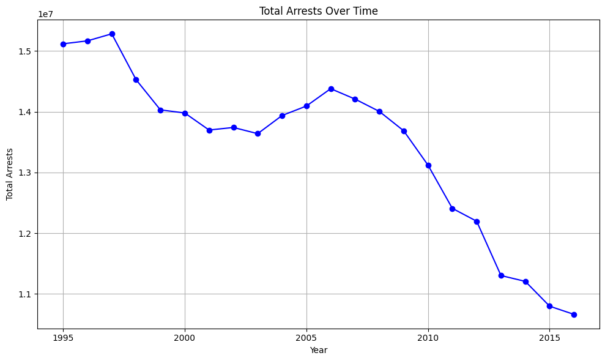

```python
plt.figure(figsize=(10, 6))
plt.plot(df['year'], df['total_arrests'], marker='o', color='blue') # Help from ChatGPT to get started
plt.title('Total Arrests Over Time')
plt.xlabel('Year')
plt.ylabel('Total Arrests')
plt.grid(True)
plt.tight_layout() # Help from ChatGPT to make it readable
plt.show()
```

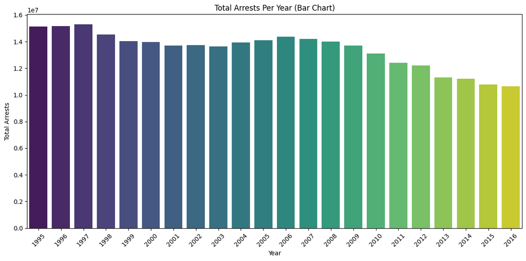

```python
#Created by ChatGPT
plt.figure(figsize=(12, 6))
sns.barplot(x='year', y='total_arrests', data=df, palette='viridis')
plt.title('Total Arrests Per Year (Bar Chart)')
plt.xlabel('Year')
plt.ylabel('Total Arrests')
plt.xticks(rotation=45)
plt.tight_layout()
plt.show()
```